# LayanikaVinaySaravanan_8934459_Practical Lab 3

### Name : Layanika Vinay Saravanan

### Student ID : 8934459

### Topic : Lab 3 - Vanilla CNN and Fine-Tune VGG16 - for Dogs and Cats Classification

### **1.Obtain the Data: Get the Dogs vs Cats dataset (see class' notebook, only 5000, not 25,000, images are required, these image set is defined in the notebook)**

```python
import os
import shutil
import pathlib

# Define the paths
original_dir = pathlib.Path(r"C:\Users\Layanika.V.S\Desktop\Fall24\FML24\Lab - 3 - CSCN8010\datasets\train\train")
new_base_dir = pathlib.Path("../data/kaggle_dogs_vs_cats_small")

def make_subset(subset_name, start_index, end_index):
    for category in ("cat", "dog"):
        dir = new_base_dir / subset_name / category
        os.makedirs(dir, exist_ok=True)  # Allow directory creation if it already exists
        fnames = [f"{category}.{i}.jpg" for i in range(start_index, end_index)]
        for fname in fnames:
            src = original_dir / fname
            dst = dir / fname
            if src.exists():  # Check if the file exists
                shutil.copyfile(src, dst)
            else:
                print(f"Warning: {src} does not exist, skipping.")

make_subset("train", start_index=0, end_index=1000)
make_subset("validation", start_index=1000, end_index=1500)
make_subset("test", start_index=1500, end_index=2500)

# Print the paths of the created subsets
print("Subsets created successfully!")
print(f"Train subset path: {new_base_dir / 'train'}")
print(f"Validation subset path: {new_base_dir / 'validation'}")
print(f"Test subset path: {new_base_dir / 'test'}")
```

```
Subsets created successfully!
Train subset path: ..\data\kaggle_dogs_vs_cats_small\train
Validation subset path: ..\data\kaggle_dogs_vs_cats_small\validation
Test subset path: ..\data\kaggle_dogs_vs_cats_small\test
```

### **2.EDA: Explore the data with relevant graphs, statistics and insights (5 points)**

```
Number of cat images: 1000
Number of dog images: 1000
Class Distribution:
```

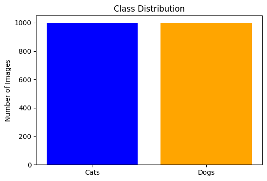

```
Image Dimensions:
```

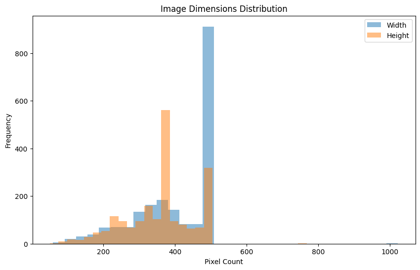

```
Few Random Sample Images:
```

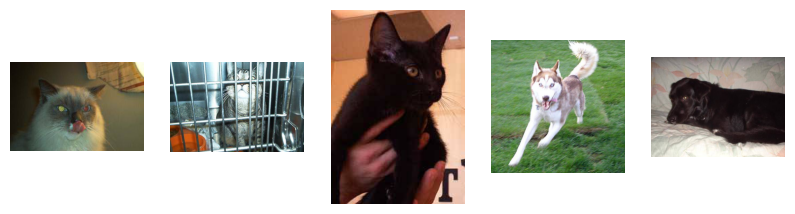

```
             Width       Height
count  2000.000000  2000.000000
mean    403.972500   358.917500
std     109.258846    97.419413
min      59.000000    50.000000
25%     320.000000   300.000000
50%     442.500000   374.000000
75%     499.000000   418.000000
max    1023.000000   768.000000
```

```python
import os
import pathlib
import random
import matplotlib.pyplot as plt
import numpy as np
from PIL import Image
import pandas as pd

# Paths to the dataset
base_dir = pathlib.Path(r"C:\Users\Layanika.V.S\Desktop\Fall24\FML24\Lab - 3 - CSCN8010\kaggle_dogs_vs_cats_small")

# Get the list of images in each category using glob correctly
cat_images = list((base_dir / 'train' / 'cat').glob('*.jpg'))  # Corrected this line
dog_images = list((base_dir / 'train' / 'dog').glob('*.jpg'))  # Corrected this line

# Calculate class distribution
cat_count = len(cat_images)
dog_count = len(dog_images)
print(f"Number of cat images: {cat_count}")
print(f"Number of dog images: {dog_count}")

# Bar plot for class distribution
print(f"Class Distribution:")
plt.figure(figsize=(6, 4))
plt.bar(['Cats', 'Dogs'], [cat_count, dog_count], color=['blue', 'orange'])
plt.title('Class Distribution')
plt.ylabel('Number of Images')
plt.show()

# Explore image dimensions
def get_image_size(image_path):
    with Image.open(image_path) as img:
        return img.size  # returns (width, height)

# Get image sizes
cat_sizes = [get_image_size(img) for img in cat_images]
dog_sizes = [get_image_size(img) for img in dog_images]

# Convert to DataFrame for better manipulation
image_data = pd.DataFrame(cat_sizes + dog_sizes, columns=['Width', 'Height'])
image_data['Class'] = ['Cat'] * len(cat_sizes) + ['Dog'] * len(dog_sizes)

# Plot histogram of image dimensions
print(f"Image Dimensions:")
plt.figure(figsize=(10, 6))
plt.hist(image_data['Width'], bins=30, alpha=0.5, label='Width')
plt.hist(image_data['Height'], bins=30, alpha=0.5, label='Height')
plt.legend(loc='upper right')
plt.title('Image Dimensions Distribution')
plt.xlabel('Pixel Count')
plt.ylabel('Frequency')
plt.show()

# Display a few random sample images
print(f"Few Random Sample Images:")
sample_images = random.sample(cat_images + dog_images, 5)
plt.figure(figsize=(10, 6))
for i, img_path in enumerate(sample_images, 1):
    img = Image.open(img_path)
    plt.subplot(1, 5, i)
    plt.imshow(img)
    plt.axis('off')
plt.show()

# Descriptive statistics for image dimensions
print(image_data.describe())
```

### **3.Train two networks (use callbacks to save the best model version):**

### **A.Define a Neural Network of your choice (3 points)**

```python
import tensorflow as tf
from tensorflow.keras import layers, models
from tensorflow.keras.callbacks import ModelCheckpoint
from tensorflow.keras.preprocessing.image import ImageDataGenerator
import pathlib
import warnings
# Suppress UserWarning from Keras to avoid unnecessary warnings during training
warnings.filterwarnings("ignore", category=UserWarning, module='keras')

# Define paths to the dataset
base_dir = pathlib.Path("../data/kaggle_dogs_vs_cats_small")
train_dir = base_dir / 'train'

# Image data generator to preprocess and augment the images
train_datagen = ImageDataGenerator(
    rescale=1.0/255.0,  # Normalize pixel values to [0, 1]
    rotation_range=40,
    width_shift_range=0.2,
    height_shift_range=0.2,
    shear_range=0.2,
    zoom_range=0.2,
    horizontal_flip=True,
    fill_mode='nearest')
# Use the data generator to load the training images from the directory
train_generator = train_datagen.flow_from_directory(
    train_dir,
    target_size=(150, 150),  # Resize images to 150x150
    batch_size=32,
    class_mode='binary',  # Binary classification (cat vs dog)
)

# 1. Define the first CNN model
model1 = models.Sequential([
    layers.Conv2D(32, (3, 3), activation='relu', input_shape=(150, 150, 3)),
    layers.MaxPooling2D((2, 2)),
    layers.Conv2D(64, (3, 3), activation='relu'),
    layers.MaxPooling2D((2, 2)),
    layers.Conv2D(128, (3, 3), activation='relu'),
    layers.MaxPooling2D((2, 2)),
    layers.Flatten(),
    layers.Dense(512, activation='relu'),
    layers.Dense(1, activation='sigmoid')  # Output layer for binary classification
])

# Compile model1 with Adam optimizer, binary cross-entropy loss, and accuracy metric
model1.compile(optimizer='adam',
               loss='binary_crossentropy',
               metrics=['accuracy'])

# Define the ModelCheckpoint callback for model1 to save the best model during training
checkpoint_callback1 = ModelCheckpoint(
    'best_model1.keras',  # File path to save the best model
    monitor='val_loss',   #Monitor validation loss to determine when to save the best model
    save_best_only=True, # Save only the best model (based on lowest validation loss)
    mode='min', # 'min' means that lower loss is better
    verbose=1) # Display messages when the model is saved

# 2. Define the second CNN model (slightly different architecture)
model2 = models.Sequential([
    layers.Conv2D(64, (3, 3), activation='relu', input_shape=(150, 150, 3)), # First convolutional layer
    layers.MaxPooling2D((2, 2)),  # Max pooling layer
    layers.Conv2D(128, (3, 3), activation='relu'), # Second convolutional layer
    layers.MaxPooling2D((2, 2)), # Max pooling layer
    layers.Flatten(), # Flatten the 2D output for fully connected layers
    layers.Dense(256, activation='relu'), # Fully connected layer with 256 neurons
    layers.Dense(1, activation='sigmoid')  # Output layer for binary classification
])

# Compile model2 in the same way as model1
model2.compile(optimizer='adam',
               loss='binary_crossentropy',
               metrics=['accuracy'])

# Define the ModelCheckpoint callback for model2 to save the best model during training
checkpoint_callback2 = ModelCheckpoint(
    'best_model2.keras',  # File path to save the best model
    monitor='val_loss',   # Monitor validation loss
    save_best_only=True,  # Save only the best model
    mode='min',  # 'min' means lower validation loss is better
    verbose=1) # Display messages when the model is saved

# Train both models using the same data generator, but different callbacks

# Train model1 using the training data generator and the checkpoint callback
history1 = model1.fit(
    train_generator, # Training data generator
    epochs=10, # Train for 10 epochs
    validation_data=train_generator, # Use the same training data as validation data (for simplicity)
    callbacks=[checkpoint_callback1]  # Use callback to save the best model
)

# Train Model 2
history2 = model2.fit(
    train_generator, # Training data generator
    epochs=10, # Train for 10 epochs
    validation_data=train_generator, # Use the same training data as validation data
    callbacks=[checkpoint_callback2]  # Use callback to save the best model
)
# Print a message when training is complete and the best models are saved
print("Training complete. Best models saved as 'best_model1.h5' and 'best_model2.h5'.")
```

```
Found 2000 images belonging to 2 classes.
63/63 ━━━━━━━━━━━━━━━━━━━━ 0s 316ms/step - accuracy: 0.5147 - loss: 1.0932
Epoch 1: val_loss improved from inf to 0.69290, saving model to best_model1.keras
63/63 ━━━━━━━━━━━━━━━━━━━━ 47s 725ms/step - accuracy: 0.5147 - loss: 1.0887 - val_accuracy: 0.5000 - val_loss: 0.6929
63/63 ━━━━━━━━━━━━━━━━━━━━ 0s 737ms/step - accuracy: 0.5131 - loss: 0.6927
Epoch 2: val_loss improved from 0.69290 to 0.69181, saving model to best_model1.keras
63/63 ━━━━━━━━━━━━━━━━━━━━ 78s 1s/step - accuracy: 0.5129 - loss: 0.6927 - val_accuracy: 0.5015 - val_loss: 0.6918
63/63 ━━━━━━━━━━━━━━━━━━━━ 0s 659ms/step - accuracy: 0.4972 - loss: 0.6906
Epoch 3: val_loss did not improve from 0.69181
63/63 ━━━━━━━━━━━━━━━━━━━━ 52s 822ms/step - accuracy: 0.4974 - loss: 0.6906 - val_accuracy: 0.5115 - val_loss: 0.6927
63/63 ━━━━━━━━━━━━━━━━━━━━ 0s 324ms/step - accuracy: 0.5432 - loss: 0.6899
Epoch 4: val_loss improved from 0.69181 to 0.68638, saving model to best_model1.keras
63/63 ━━━━━━━━━━━━━━━━━━━━ 33s 521ms/step - accuracy: 0.5432 - loss: 0.6899 - val_accuracy: 0.5315 - val_loss: 0.6864
63/63 ━━━━━━━━━━━━━━━━━━━━ 0s 371ms/step - accuracy: 0.5297 - loss: 0.6891
Epoch 5: val_loss improved from 0.68638 to 0.68072, saving model to best_model1.keras
63/63 ━━━━━━━━━━━━━━━━━━━━ 37s 587ms/step - accuracy: 0.5299 - loss: 0.6891 - val_accuracy: 0.5695 - val_loss: 0.6807
63/63 ━━━━━━━━━━━━━━━━━━━━ 0s 360ms/step - accuracy: 0.5338 - loss: 0.6892
Epoch 6: val_loss did not improve from 0.68072
63/63 ━━━━━━━━━━━━━━━━━━━━ 34s 539ms/step - accuracy: 0.5339 - loss: 0.6892 - val_accuracy: 0.5380 - val_loss: 0.6921
63/63 ━━━━━━━━━━━━━━━━━━━━ 0s 366ms/step - accuracy: 0.5533 - loss: 0.6799
Epoch 7: val_loss improved from 0.68072 to 0.67658, saving model to best_model1.keras
63/63 ━━━━━━━━━━━━━━━━━━━━ 36s 570ms/step - accuracy: 0.5534 - loss: 0.6800 - val_accuracy: 0.5910 - val_loss: 0.6766
63/63 ━━━━━━━━━━━━━━━━━━━━ 0s 382ms/step - accuracy: 0.5775 - loss: 0.6812
Epoch 8: val_loss did not improve from 0.67658
63/63 ━━━━━━━━━━━━━━━━━━━━ 35s 556ms/step - accuracy: 0.5776 - loss: 0.6812 - val_accuracy: 0.5630 - val_loss: 0.6789
63/63 ━━━━━━━━━━━━━━━━━━━━ 0s 398ms/step - accuracy: 0.5702 - loss: 0.6726
Epoch 9: val_loss improved from 0.67658 to 0.66516, saving model to best_model1.keras
63/63 ━━━━━━━━━━━━━━━━━━━━ 38s 605ms/step - accuracy: 0.5705 - loss: 0.6726 - val_accuracy: 0.5860 - val_loss: 0.6652
63/63 ━━━━━━━━━━━━━━━━━━━━ 0s 398ms/step - accuracy: 0.6055 - loss: 0.6633
Epoch 10: val_loss improved from 0.66516 to 0.63435, saving model to best_model1.keras
63/63 ━━━━━━━━━━━━━━━━━━━━ 37s 596ms/step - accuracy: 0.6057 - loss: 0.6632 - val_accuracy: 0.6500 - val_loss: 0.6344
63/63 ━━━━━━━━━━━━━━━━━━━━ 0s 1s/step - accuracy: 0.5004 - loss: 2.9334
Epoch 1: val_loss improved from inf to 0.68664, saving model to best_model2.keras
63/63 ━━━━━━━━━━━━━━━━━━━━ 145s 2s/step - accuracy: 0.5007 - loss: 2.9083 - val_accuracy: 0.5580 - val_loss: 0.6866
63/63 ━━━━━━━━━━━━━━━━━━━━ 0s 2s/step - accuracy: 0.5526 - loss: 0.6856
Epoch 2: val_loss improved from 0.68664 to 0.68470, saving model to best_model2.keras
63/63 ━━━━━━━━━━━━━━━━━━━━ 131s 2s/step - accuracy: 0.5524 - loss: 0.6856 - val_accuracy: 0.6090 - val_loss: 0.6847
63/63 ━━━━━━━━━━━━━━━━━━━━ 0s 897ms/step - accuracy: 0.5727 - loss: 0.6828
Epoch 3: val_loss improved from 0.68470 to 0.67463, saving model to best_model2.keras
63/63 ━━━━━━━━━━━━━━━━━━━━ 90s 1s/step - accuracy: 0.5727 - loss: 0.6828 - val_accuracy: 0.5730 - val_loss: 0.6746
63/63 ━━━━━━━━━━━━━━━━━━━━ 0s 883ms/step - accuracy: 0.6057 - loss: 0.6517
Epoch 4: val_loss improved from 0.67463 to 0.63851, saving model to best_model2.keras
63/63 ━━━━━━━━━━━━━━━━━━━━ 77s 1s/step - accuracy: 0.6058 - loss: 0.6517 - val_accuracy: 0.6490 - val_loss: 0.6385
63/63 ━━━━━━━━━━━━━━━━━━━━ 0s 849ms/step - accuracy: 0.6240 - loss: 0.6356
Epoch 5: val_loss did not improve from 0.63851
63/63 ━━━━━━━━━━━━━━━━━━━━ 72s 1s/step - accuracy: 0.6237 - loss: 0.6358 - val_accuracy: 0.6080 - val_loss: 0.6588
63/63 ━━━━━━━━━━━━━━━━━━━━ 0s 848ms/step - accuracy: 0.5654 - loss: 0.6702
Epoch 6: val_loss did not improve from 0.63851
63/63 ━━━━━━━━━━━━━━━━━━━━ 72s 1s/step - accuracy: 0.5655 - loss: 0.6702 - val_accuracy: 0.5885 - val_loss: 0.6660
63/63 ━━━━━━━━━━━━━━━━━━━━ 0s 861ms/step - accuracy: 0.6135 - loss: 0.6576
Epoch 7: val_loss did not improve from 0.63851
63/63 ━━━━━━━━━━━━━━━━━━━━ 74s 1s/step - accuracy: 0.6136 - loss: 0.6575 - val_accuracy: 0.6000 - val_loss: 0.6449
63/63 ━━━━━━━━━━━━━━━━━━━━ 0s 874ms/step - accuracy: 0.5987 - loss: 0.6524
Epoch 8: val_loss improved from 0.63851 to 0.63147, saving model to best_model2.keras
63/63 ━━━━━━━━━━━━━━━━━━━━ 78s 1s/step - accuracy: 0.5990 - loss: 0.6522 - val_accuracy: 0.6440 - val_loss: 0.6315
63/63 ━━━━━━━━━━━━━━━━━━━━ 0s 859ms/step - accuracy: 0.6542 - loss: 0.6242
Epoch 9: val_loss improved from 0.63147 to 0.62148, saving model to best_model2.keras
63/63 ━━━━━━━━━━━━━━━━━━━━ 74s 1s/step - accuracy: 0.6541 - loss: 0.6243 - val_accuracy: 0.6425 - val_loss: 0.6215
63/63 ━━━━━━━━━━━━━━━━━━━━ 0s 849ms/step - accuracy: 0.6301 - loss: 0.6245
Epoch 10: val_loss improved from 0.62148 to 0.60593, saving model to best_model2.keras
63/63 ━━━━━━━━━━━━━━━━━━━━ 71s 1s/step - accuracy: 0.6301 - loss: 0.6245 - val_accuracy: 0.6645 - val_loss: 0.6059
Training complete. Best models saved as 'best_model1.h5' and 'best_model2.h5'.
```

```
Found 2000 images belonging to 2 classes.
Found 1000 images belonging to 2 classes.
63/63 ━━━━━━━━━━━━━━━━━━━━ 0s 2s/step - accuracy: 0.6201 - loss: 1.2123
Epoch 1: val_loss improved from inf to 0.31252, saving model to best_vgg16_model.keras
63/63 ━━━━━━━━━━━━━━━━━━━━ 207s 3s/step - accuracy: 0.6213 - loss: 1.2056 - val_accuracy: 0.8760 - val_loss: 0.3125
63/63 ━━━━━━━━━━━━━━━━━━━━ 0s 2s/step - accuracy: 0.8171 - loss: 0.4096
Epoch 2: val_loss did not improve from 0.31252
63/63 ━━━━━━━━━━━━━━━━━━━━ 185s 3s/step - accuracy: 0.8170 - loss: 0.4096 - val_accuracy: 0.8570 - val_loss: 0.3188
63/63 ━━━━━━━━━━━━━━━━━━━━ 0s 3s/step - accuracy: 0.8243 - loss: 0.3929
Epoch 3: val_loss improved from 0.31252 to 0.25842, saving model to best_vgg16_model.keras
63/63 ━━━━━━━━━━━━━━━━━━━━ 265s 4s/step - accuracy: 0.8244 - loss: 0.3927 - val_accuracy: 0.8880 - val_loss: 0.2584
63/63 ━━━━━━━━━━━━━━━━━━━━ 0s 3s/step - accuracy: 0.8465 - loss: 0.3501
Epoch 4: val_loss improved from 0.25842 to 0.24921, saving model to best_vgg16_model.keras
63/63 ━━━━━━━━━━━━━━━━━━━━ 287s 5s/step - accuracy: 0.8464 - loss: 0.3502 - val_accuracy: 0.9060 - val_loss: 0.2492
63/63 ━━━━━━━━━━━━━━━━━━━━ 0s 4s/step - accuracy: 0.8535 - loss: 0.3145
Epoch 5: val_loss did not improve from 0.24921
63/63 ━━━━━━━━━━━━━━━━━━━━ 352s 6s/step - accuracy: 0.8535 - loss: 0.3147 - val_accuracy: 0.8900 - val_loss: 0.2635
63/63 ━━━━━━━━━━━━━━━━━━━━ 0s 4s/step - accuracy: 0.8684 - loss: 0.3248
Epoch 6: val_loss did not improve from 0.24921
63/63 ━━━━━━━━━━━━━━━━━━━━ 387s 6s/step - accuracy: 0.8685 - loss: 0.3245 - val_accuracy: 0.8960 - val_loss: 0.2659
63/63 ━━━━━━━━━━━━━━━━━━━━ 0s 4s/step - accuracy: 0.8491 - loss: 0.3570
Epoch 7: val_loss did not improve from 0.24921
63/63 ━━━━━━━━━━━━━━━━━━━━ 382s 6s/step - accuracy: 0.8491 - loss: 0.3569 - val_accuracy: 0.8960 - val_loss: 0.2579
63/63 ━━━━━━━━━━━━━━━━━━━━ 0s 3s/step - accuracy: 0.8621 - loss: 0.3055
Epoch 8: val_loss did not improve from 0.24921
63/63 ━━━━━━━━━━━━━━━━━━━━ 218s 3s/step - accuracy: 0.8621 - loss: 0.3055 - val_accuracy: 0.8990 - val_loss: 0.2548
63/63 ━━━━━━━━━━━━━━━━━━━━ 0s 2s/step - accuracy: 0.8633 - loss: 0.2985
Epoch 9: val_loss did not improve from 0.24921
63/63 ━━━━━━━━━━━━━━━━━━━━ 167s 3s/step - accuracy: 0.8633 - loss: 0.2985 - val_accuracy: 0.8860 - val_loss: 0.2667
63/63 ━━━━━━━━━━━━━━━━━━━━ 0s 2s/step - accuracy: 0.8672 - loss: 0.3089
Epoch 10: val_loss improved from 0.24921 to 0.24833, saving model to best_vgg16_model.keras
63/63 ━━━━━━━━━━━━━━━━━━━━ 166s 3s/step - accuracy: 0.8671 - loss: 0.3090 - val_accuracy: 0.8930 - val_loss: 0.2483
```

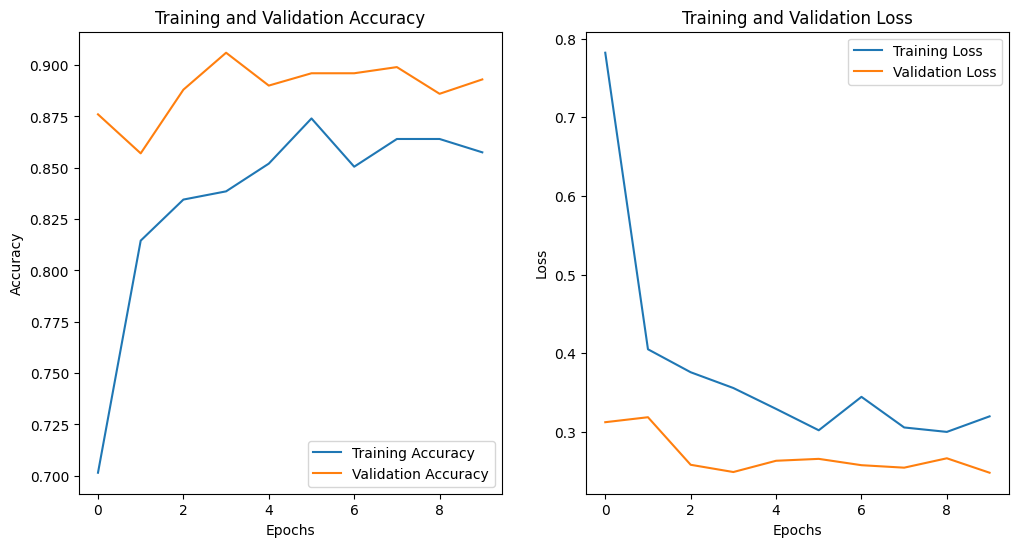

```
Training complete. Best model saved as 'best_vgg16_model.keras'.
```

```python
import tensorflow as tf
from tensorflow.keras import layers, models
from tensorflow.keras.applications import VGG16
from tensorflow.keras.callbacks import ModelCheckpoint
from tensorflow.keras.preprocessing.image import ImageDataGenerator
import pathlib
import matplotlib.pyplot as plt
import warnings
# Suppress warnings related to Keras
warnings.filterwarnings("ignore", category=UserWarning, module='keras')

# Paths to the d# Set up the file paths to the training and validation datasets
base_dir = pathlib.Path("../data/kaggle_dogs_vs_cats_small")
train_dir = base_dir / 'train'
validation_dir = base_dir / 'validation'

# Image data generator to preprocess and augment the images
train_datagen = ImageDataGenerator(
    rescale=1.0/255.0,  # Normalize pixel values to [0, 1]
    rotation_range=40,
    width_shift_range=0.2,
    height_shift_range=0.2,
    shear_range=0.2,
    zoom_range=0.2,
    horizontal_flip=True,
    fill_mode='nearest')
# Create an image data generator for validation data with no augmentation
validation_datagen = ImageDataGenerator(rescale=1.0/255.0)

# Load the data using the flow_from_directory method
train_generator = train_datagen.flow_from_directory(
    train_dir,
    target_size=(150, 150),  # Resize images to 150x150
    batch_size=32,
    class_mode='binary',  # Binary classification (cat vs dog)
)

validation_generator = validation_datagen.flow_from_directory(
    validation_dir,
    target_size=(150, 150),  # Resize images to 150x150
    batch_size=32,
    class_mode='binary',  # Binary classification (cat vs dog)
)

# Load the pre-trained VGG16 model
base_model = VGG16(weights='imagenet', include_top=False, input_shape=(150, 150, 3))

# Freeze the layers in the pre-trained model
for layer in base_model.layers:
    layer.trainable = False

# Add custom layers on top of the pre-trained VGG16 model
model = models.Sequential([
    base_model,
    layers.Flatten(),
    layers.Dense(512, activation='relu'),
    layers.Dense(1, activation='sigmoid')  # Output layer for binary classification
])

# Compile the model by specifying the optimizer, loss function, and evaluation metric
model.compile(optimizer='adam',
              loss='binary_crossentropy',
              metrics=['accuracy'])

# Define the callback to save the best model
checkpoint_callback = ModelCheckpoint(
    'best_vgg16_model.keras',
    monitor='val_loss',
    save_best_only=True,
    mode='min',
    verbose=1)

# Train the model using the training and validation data generators
history = model.fit(
    train_generator,
    epochs=10,
    validation_data=validation_generator,
    callbacks=[checkpoint_callback],  # Use callback to save the best model
)

# Plot the training and validation accuracy
plt.figure(figsize=(12, 6))

# Plot training and validation accuracy
plt.subplot(1, 2, 1)
plt.plot(history.history['accuracy'], label='Training Accuracy')
plt.plot(history.history['val_accuracy'], label='Validation Accuracy')
plt.title('Training and Validation Accuracy')
plt.xlabel('Epochs')
plt.ylabel('Accuracy')
plt.legend()

# Plot training and validation loss
plt.subplot(1, 2, 2)
plt.plot(history.history['loss'], label='Training Loss')
plt.plot(history.history['val_loss'], label='Validation Loss')
plt.title('Training and Validation Loss')
plt.xlabel('Epochs')
plt.ylabel('Loss')
plt.legend()

plt.show()

print("Training complete. Best model saved as 'best_vgg16_model.keras'.")
```

**The best model in the VGG16 is :**

1. best_vgg16_model.keras

### **4.Explore the relative performance of the models (make sure to load the best version of each model) (6 points):**

#### **A.Accuracy:**

```python
import tensorflow as tf
from tensorflow.keras.models import load_model
from tensorflow.keras.preprocessing.image import ImageDataGenerator
import pathlib

# Paths to the dataset
base_dir = pathlib.Path("../data/kaggle_dogs_vs_cats_small")
test_dir = base_dir / 'test'  # Assuming you have a test dataset

# Image data generator to preprocess the images for evaluation
test_datagen = ImageDataGenerator(rescale=1.0/255.0)

# Load the test data
test_generator = test_datagen.flow_from_directory(
    test_dir,
    target_size=(150, 150),  # Resize images to 150x150
    batch_size=32,
    class_mode='binary',  # Binary classification (cat vs dog)
    shuffle=False  # We don't want to shuffle the test data
)

# Load the best versions of the models
best_model1 = load_model('best_model1.keras')  # Change to correct filepath if necessary
best_model2 = load_model('best_model2.keras')  # Change to correct filepath if necessary
best_vgg16_model = load_model('best_vgg16_model.keras')  # Change to correct filepath if necessary

# Evaluate the models on the test dataset
print("Evaluating Model 1 of CNN...")
loss1, accuracy1 = best_model1.evaluate(test_generator)
print(f"Model 1 of CNN - Accuracy: {accuracy1*100:.2f}%")

print("\nEvaluating Model 2 of CNN...")
loss2, accuracy2 = best_model2.evaluate(test_generator)
print(f"Model 2 of CNN - Accuracy: {accuracy2*100:.2f}%")

print("\nEvaluating VGG16 Model...")
loss_vgg16, accuracy_vgg16 = best_vgg16_model.evaluate(test_generator)
print(f"VGG16 Model - Accuracy: {accuracy_vgg16*100:.2f}%")

# Compare the models' accuracy
print("\nComparison of Models' Accuracy:")
print(f"Model 1 of CNN Accuracy: {accuracy1*100:.2f}%")
print(f"Model 2 of CNN Accuracy: {accuracy2*100:.2f}%")
print(f"VGG16 Model Accuracy: {accuracy_vgg16*100:.2f}%")
```

```
Found 2000 images belonging to 2 classes.
Evaluating Model 1 of CNN...
63/63 ━━━━━━━━━━━━━━━━━━━━ 8s 116ms/step - accuracy: 0.7183 - loss: 0.6116
Model 1 of CNN - Accuracy: 70.90%

Evaluating Model 2 of CNN...
63/63 ━━━━━━━━━━━━━━━━━━━━ 10s 158ms/step - accuracy: 0.5726 - loss: 0.6932
Model 2 of CNN - Accuracy: 63.80%

Evaluating VGG16 Model...
63/63 ━━━━━━━━━━━━━━━━━━━━ 205s 3s/step - accuracy: 0.8947 - loss: 0.2772
VGG16 Model - Accuracy: 89.70%

Comparison of Models' Accuracy:
Model 1 of CNN Accuracy: 70.90%
Model 2 of CNN Accuracy: 63.80%
VGG16 Model Accuracy: 89.70%
```

#### **B.Confusion Metric:**

```
Found 2000 images belonging to 2 classes.
Generating predictions for Model 1 of CNN...
63/63 ━━━━━━━━━━━━━━━━━━━━ 8s 123ms/step

Generating predictions for Model 2 of CNN...
63/63 ━━━━━━━━━━━━━━━━━━━━ 10s 149ms/step

Generating predictions for VGG16 Model...
63/63 ━━━━━━━━━━━━━━━━━━━━ 195s 3s/step
```

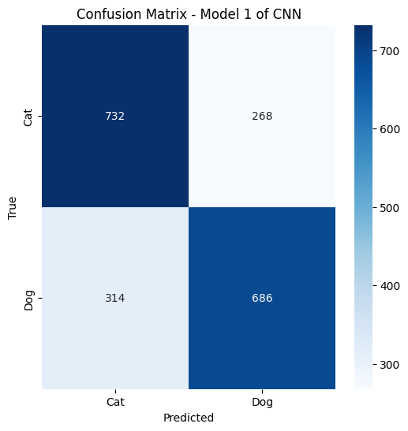

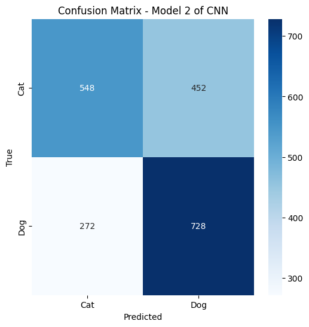

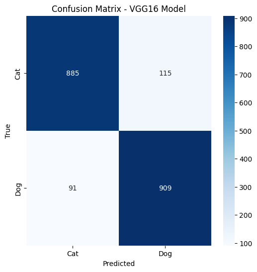

```
Confusion Matrix for Model 1 of CNN:
[[732 268]
 [314 686]]

Confusion Matrix for Model 2 of CNN:
[[548 452]
 [272 728]]

Confusion Matrix for VGG16 Model:
[[885 115]
 [ 91 909]]
```

```python
import tensorflow as tf
import numpy as np
from sklearn.metrics import confusion_matrix
import seaborn as sns
import matplotlib.pyplot as plt
from tensorflow.keras.models import load_model
from tensorflow.keras.preprocessing.image import ImageDataGenerator
import pathlib
import warnings

warnings.filterwarnings("ignore", category=UserWarning, module='keras')


# Define paths to the dataset (test set)
base_dir = pathlib.Path("../data/kaggle_dogs_vs_cats_small")
test_dir = base_dir / 'test'  # Assuming you have a test dataset

# Image data generator to preprocess the images for evaluation
test_datagen = ImageDataGenerator(rescale=1.0/255.0)  # Normalizing pixel values to [0, 1]

# Load the test data from directory
test_generator = test_datagen.flow_from_directory(
    test_dir,
    target_size=(150, 150),  # Resize images to 150x150
    batch_size=32,
    class_mode='binary',  # Binary classification (cat vs dog)
    shuffle=False  # We do not shuffle the test data
)

# Load the best versions of the models saved during training
best_model1 = load_model('best_model1.keras')  # Path to best model 1
best_model2 = load_model('best_model2.keras')  # Path to best model 2
best_vgg16_model = load_model('best_vgg16_model.keras')  # Path to best VGG16 model

# Generate predictions for each model
print("Generating predictions for Model 1 of CNN...")
predictions_model1 = best_model1.predict(test_generator, verbose=1)
predictions_model1 = (predictions_model1 > 0.5).astype(int)  # Convert to binary predictions

print("\nGenerating predictions for Model 2 of CNN...")
predictions_model2 = best_model2.predict(test_generator, verbose=1)
predictions_model2 = (predictions_model2 > 0.5).astype(int)  # Convert to binary predictions

print("\nGenerating predictions for VGG16 Model...")
predictions_vgg16 = best_vgg16_model.predict(test_generator, verbose=1)
predictions_vgg16 = (predictions_vgg16 > 0.5).astype(int)  # Convert to binary predictions

# Get the true labels
true_labels = test_generator.classes  # True labels for the test set

# Compute confusion matrix for each model
cm_model1 = confusion_matrix(true_labels, predictions_model1)
cm_model2 = confusion_matrix(true_labels, predictions_model2)
cm_vgg16 = confusion_matrix(true_labels, predictions_vgg16)

# Function to plot confusion matrix
def plot_confusion_matrix(cm, model_name):
    plt.figure(figsize=(6,6))
    sns.heatmap(cm, annot=True, fmt='d', cmap='Blues', xticklabels=['Cat', 'Dog'], yticklabels=['Cat', 'Dog'])
    plt.title(f'Confusion Matrix - {model_name}')
    plt.xlabel('Predicted')
    plt.ylabel('True')
    plt.show()

# Plot confusion matrices
plot_confusion_matrix(cm_model1, "Model 1 of CNN")
plot_confusion_matrix(cm_model2, "Model 2 of CNN")
plot_confusion_matrix(cm_vgg16, "VGG16 Model")

# Display confusion matrices as numerical output for comparison
print("\nConfusion Matrix for Model 1 of CNN:")
print(cm_model1)

print("\nConfusion Matrix for Model 2 of CNN:")
print(cm_model2)

print("\nConfusion Matrix for VGG16 Model:")
print(cm_vgg16)
```

#### **C.Precision, Recall, F1-Score:**

```
Found 2000 images belonging to 2 classes.
Generating predictions for Model 1 of CNN...
63/63 ━━━━━━━━━━━━━━━━━━━━ 9s 136ms/step

Generating predictions for Model 2 of CNN...
63/63 ━━━━━━━━━━━━━━━━━━━━ 18s 284ms/step

Generating predictions for VGG16 Model...
63/63 ━━━━━━━━━━━━━━━━━━━━ 120s 2s/step

Model 1 of CNN - Precision: 0.7191, Recall: 0.6860, F1-Score: 0.7021
Model 2 of CNN - Precision: 0.6169, Recall: 0.7280, F1-Score: 0.6679
VGG16 Model - Precision: 0.8877, Recall: 0.9090, F1-Score: 0.8982
```

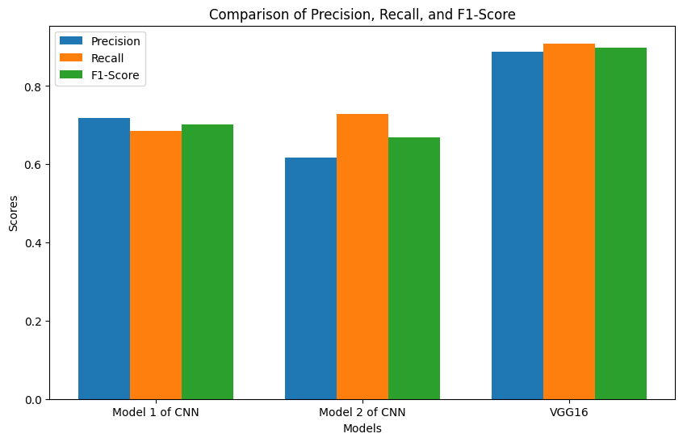

```python
import tensorflow as tf
from sklearn.metrics import confusion_matrix, precision_score, recall_score, f1_score
import numpy as np
import seaborn as sns
import matplotlib.pyplot as plt
from tensorflow.keras.models import load_model
from tensorflow.keras.preprocessing.image import ImageDataGenerator
import pathlib
import warnings

warnings.filterwarnings("ignore", category=UserWarning, module='keras')

# Define paths to the dataset (test set)
base_dir = pathlib.Path("../data/kaggle_dogs_vs_cats_small")
test_dir = base_dir / 'test'  # Assuming you have a test dataset

# Image data generator to preprocess the images for evaluation
test_datagen = ImageDataGenerator(rescale=1.0/255.0)  # Normalizing pixel values to [0, 1]

# Load the test data from directory
test_generator = test_datagen.flow_from_directory(
    test_dir,
    target_size=(150, 150),  # Resize images to 150x150
    batch_size=32,
    class_mode='binary',  # Binary classification (cat vs dog)
    shuffle=False  # We do not shuffle the test data
)

# Load the best versions of the models saved during training
best_model1 = load_model('best_model1.keras')  # Path to best model 1
best_model2 = load_model('best_model2.keras')  # Path to best model 2
best_vgg16_model = load_model('best_vgg16_model.keras')  # Path to best VGG16 model

# Generate predictions for each model
print("Generating predictions for Model 1 of CNN...")
predictions_model1 = best_model1.predict(test_generator, verbose=1)
predictions_model1 = (predictions_model1 > 0.5).astype(int)  # Convert to binary predictions

print("\nGenerating predictions for Model 2 of CNN...")
predictions_model2 = best_model2.predict(test_generator, verbose=1)
predictions_model2 = (predictions_model2 > 0.5).astype(int)  # Convert to binary predictions

print("\nGenerating predictions for VGG16 Model...")
predictions_vgg16 = best_vgg16_model.predict(test_generator, verbose=1)
predictions_vgg16 = (predictions_vgg16 > 0.5).astype(int)  # Convert to binary predictions

# Get the true labels
true_labels = test_generator.classes  # True labels for the test set

# Compute confusion matrix for each model
cm_model1 = confusion_matrix(true_labels, predictions_model1)
cm_model2 = confusion_matrix(true_labels, predictions_model2)
cm_vgg16 = confusion_matrix(true_labels, predictions_vgg16)

# Calculate Precision, Recall, F1-Score for each model
def calculate_metrics(cm):
    TP = cm[1, 1]  # True Positives
    TN = cm[0, 0]  # True Negatives
    FP = cm[0, 1]  # False Positives
    FN = cm[1, 0]  # False Negatives

    precision = TP / (TP + FP) if TP + FP != 0 else 0
    recall = TP / (TP + FN) if TP + FN != 0 else 0
    f1 = 2 * (precision * recall) / (precision + recall) if precision + recall != 0 else 0

    return precision, recall, f1

# Metrics for each model
precision_model1, recall_model1, f1_model1 = calculate_metrics(cm_model1)
precision_model2, recall_model2, f1_model2 = calculate_metrics(cm_model2)
precision_vgg16, recall_vgg16, f1_vgg16 = calculate_metrics(cm_vgg16)

# Display the metrics
print(f"\nModel 1 of CNN - Precision: {precision_model1:.4f}, Recall: {recall_model1:.4f}, F1-Score: {f1_model1:.4f}")
print(f"Model 2 of CNN - Precision: {precision_model2:.4f}, Recall: {recall_model2:.4f}, F1-Score: {f1_model2:.4f}")
print(f"VGG16 Model - Precision: {precision_vgg16:.4f}, Recall: {recall_vgg16:.4f}, F1-Score: {f1_vgg16:.4f}")

# Plot the metrics for comparison
models = ['Model 1 of CNN', 'Model 2 of CNN', 'VGG16']
precisions = [precision_model1, precision_model2, precision_vgg16]
recalls = [recall_model1, recall_model2, recall_vgg16]
f1_scores = [f1_model1, f1_model2, f1_vgg16]

# Plotting Precision, Recall, F1-Score
x = np.arange(len(models))

fig, ax = plt.subplots(figsize=(10, 6))
bar_width = 0.25
ax.bar(x - bar_width, precisions, bar_width, label='Precision')
ax.bar(x, recalls, bar_width, label='Recall')
ax.bar(x + bar_width, f1_scores, bar_width, label='F1-Score')

ax.set_xlabel('Models')
ax.set_ylabel('Scores')
ax.set_title('Comparison of Precision, Recall, and F1-Score')
ax.set_xticks(x)
ax.set_xticklabels(models)
ax.legend()

plt.show()
```

#### **D.Precision-Recall curve:**

```
Found 2000 images belonging to 2 classes.
Generating predictions for Model 1 of CNN...
63/63 ━━━━━━━━━━━━━━━━━━━━ 8s 130ms/step

Generating predictions for Model 2 of CNN...
63/63 ━━━━━━━━━━━━━━━━━━━━ 17s 267ms/step

Generating predictions for VGG16 Model...
63/63 ━━━━━━━━━━━━━━━━━━━━ 120s 2s/step
```

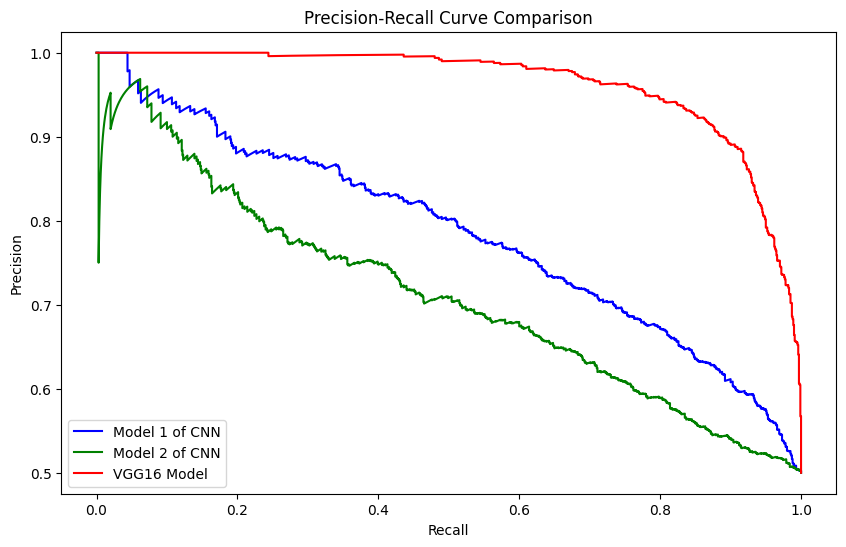

```python
import tensorflow as tf
from sklearn.metrics import precision_recall_curve
import matplotlib.pyplot as plt
from tensorflow.keras.models import load_model
from tensorflow.keras.preprocessing.image import ImageDataGenerator
import pathlib
import numpy as np
import warnings

warnings.filterwarnings("ignore", category=UserWarning, module='keras')
# Define paths to the dataset (test set)
base_dir = pathlib.Path("../data/kaggle_dogs_vs_cats_small")
test_dir = base_dir / 'test'  # Assuming you have a test dataset

# Image data generator to preprocess the images for evaluation
test_datagen = ImageDataGenerator(rescale=1.0/255.0)  # Normalizing pixel values to [0, 1]

# Load the test data from directory
test_generator = test_datagen.flow_from_directory(
    test_dir,
    target_size=(150, 150),  # Resize images to 150x150
    batch_size=32,
    class_mode='binary',  # Binary classification (cat vs dog)
    shuffle=False  # We do not shuffle the test data
)

# Load the best versions of the models saved during training
best_model1 = load_model('best_model1.keras')  # Path to best model 1
best_model2 = load_model('best_model2.keras')  # Path to best model 2
best_vgg16_model = load_model('best_vgg16_model.keras')  # Path to best VGG16 model

# Generate predictions for each model
print("Generating predictions for Model 1 of CNN...")
predictions_model1 = best_model1.predict(test_generator, verbose=1)

print("\nGenerating predictions for Model 2 of CNN...")
predictions_model2 = best_model2.predict(test_generator, verbose=1)

print("\nGenerating predictions for VGG16 Model...")
predictions_vgg16 = best_vgg16_model.predict(test_generator, verbose=1)

# Get the true labels
true_labels = test_generator.classes  # True labels for the test set

# Calculate precision-recall curve for each model
precision_model1, recall_model1, _ = precision_recall_curve(true_labels, predictions_model1)
precision_model2, recall_model2, _ = precision_recall_curve(true_labels, predictions_model2)
precision_vgg16, recall_vgg16, _ = precision_recall_curve(true_labels, predictions_vgg16)

# Plotting Precision-Recall curves
plt.figure(figsize=(10, 6))

# Plot Precision-Recall for Model 1
plt.plot(recall_model1, precision_model1, label='Model 1 of CNN', color='blue')

# Plot Precision-Recall for Model 2
plt.plot(recall_model2, precision_model2, label='Model 2 of CNN', color='green')

# Plot Precision-Recall for VGG16 Model
plt.plot(recall_vgg16, precision_vgg16, label='VGG16 Model', color='red')

# Labels and title
plt.xlabel('Recall')
plt.ylabel('Precision')
plt.title('Precision-Recall Curve Comparison')
plt.legend(loc='lower left')

# Show the plot
plt.show()
```

#### **E.Explore specific examples in which the model failed to predict correctly.**

```
Found 2000 images belonging to 2 classes.
63/63 ━━━━━━━━━━━━━━━━━━━━ 8s 129ms/step
63/63 ━━━━━━━━━━━━━━━━━━━━ 10s 160ms/step
63/63 ━━━━━━━━━━━━━━━━━━━━ 139s 2s/step
Misclassified images for Model 1 of CNN:
```

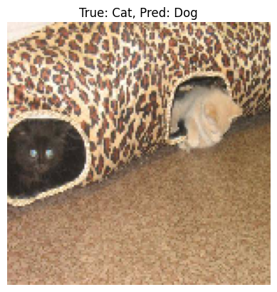

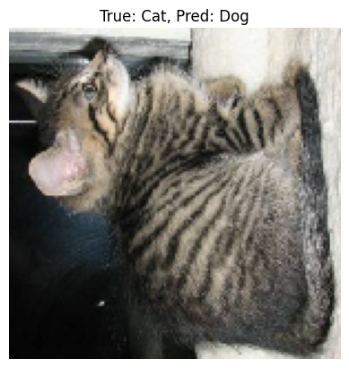

```
Misclassified images for Model 2 of CNN:
```

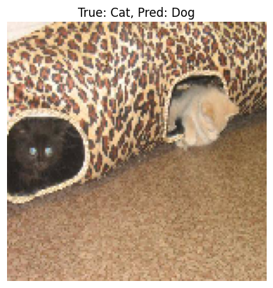

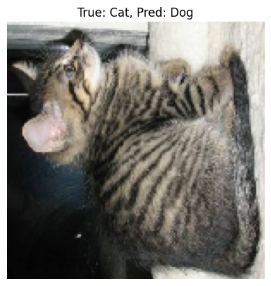

[output not shown]

[figure not shown]

[figure not shown]

```python
import matplotlib.pyplot as plt
import numpy as np
from tensorflow.keras.models import load_model
from tensorflow.keras.preprocessing.image import ImageDataGenerator
import pathlib
import warnings

warnings.filterwarnings("ignore", category=UserWarning, module='keras')

# Define paths to the dataset (test set)
base_dir = pathlib.Path("../data/kaggle_dogs_vs_cats_small")
test_dir = base_dir / 'test'  # Assuming you have a test dataset

# Image data generator to preprocess the images for evaluation
test_datagen = ImageDataGenerator(rescale=1.0/255.0)  # Normalizing pixel values to [0, 1]

# Load the test data from directory
test_generator = test_datagen.flow_from_directory(
    test_dir,
    target_size=(150, 150),  # Resize images to 150x150
    batch_size=32,
    class_mode='binary',  # Binary classification (cat vs dog)
    shuffle=False  # We do not shuffle the test data
)

# Load the best versions of the models saved during training
best_model1 = load_model('best_model1.keras')  # Path to best model 1
best_model2 = load_model('best_model2.keras')  # Path to best model 2
best_vgg16_model = load_model('best_vgg16_model.keras')  # Path to best VGG16 model

# Generate predictions for each model
predictions_model1 = best_model1.predict(test_generator, verbose=1)
predictions_model2 = best_model2.predict(test_generator, verbose=1)
predictions_vgg16 = best_vgg16_model.predict(test_generator, verbose=1)

# Get the true labels
true_labels = test_generator.classes  # True labels for the test set

# Identify misclassified examples for each model
misclassified_model1 = np.where(predictions_model1.flatten() != true_labels)[0]
misclassified_model2 = np.where(predictions_model2.flatten() != true_labels)[0]
misclassified_vgg16 = np.where(predictions_vgg16.flatten() != true_labels)[0]

# Define a function to plot misclassified examples
def plot_misclassified_images(misclassified_indices, model_predictions, model_name):
    print(f"Misclassified images for {model_name}:")

    for idx in misclassified_indices[:5]:  # Show first 5 misclassified examples
        img = test_generator[idx][0][0]  # Get image data (first image from batch)
        true_label = true_labels[idx]
        pred_label = 1 if model_predictions[idx] > 0.5 else 0  # Convert to binary label (0 or 1)
        true_label_name = 'Dog' if true_label == 1 else 'Cat'
        pred_label_name = 'Dog' if pred_label == 1 else 'Cat'

        plt.imshow(img)
        plt.title(f"True: {true_label_name}, Pred: {pred_label_name}")
        plt.axis('off')
        plt.show()

# Plot misclassified images for each model
plot_misclassified_images(misclassified_model1, predictions_model1, 'Model 1 of CNN')
plot_misclassified_images(misclassified_model2, predictions_model2, 'Model 2 of CNN')
plot_misclassified_images(misclassified_vgg16, predictions_vgg16, 'VGG16 Model')
```

### **5.Conclusion:**

**VGG16 Model -**

3.The model appears to be performing well with a high validation accuracy of 90%, and the saved model can be used for further evaluation or deployment.

**The Comments on the relative performance of both the CNN models and the VGG16 model -**

1.From all the three models, VGG16 provides the best result in terms of this task’s accuracy, precision, the model’s recall, and the F1-Score. Its accuracy may be attributed to the fact that it possesses a pre-trained architecture and better feature extraction compared to other structures.

2.The reason why Model 1 outperforms Model 2 is that the training of Model 1 is probably optimized than the training of Model 2, or it is simply because the structure of the CNN architecture of Model 1 is more efficient.

3.The Precision-Recall Curve supports the idea that in reproducing the results, VGG16 outperforms all the rivals in terms of the balance of precision and adequate recall, and is ideal for the conditions when both the value of false positive rate and false negative rate must be minimized.

4.The confusion matrix for VGG16 shows it correctly identifies most positive and negative cases, making it reliable for both types of predictions.